# hw2

**Q1**

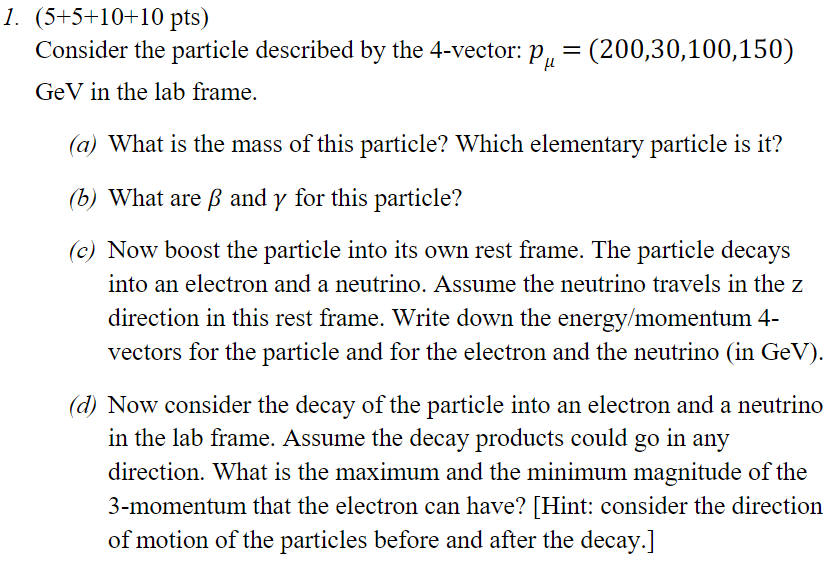

$$ p_\mu = \begin{pmatrix} 200 \\ 30 \\ 100 \\150 \end{pmatrix} = \begin{pmatrix} E/c \\ p_x \\ p_y \\ p_z \end{pmatrix} $$

(a) From the metric we have $m^2 = E^2 - p^2$

$$ |p| = \sqrt{30^2+10^2+150^2} \\ m^2 = (200c)^2 - 30^2 - 100^2 - 150^2 \\ m = 81.24 $$

This is a bit more than the rest mass of a $W$ boson $80.37$ GeV.

```python
p2 = 30**2 + 100**2 + 150**2
print('momentum magnitude: ', p2**(1/2))

E = 200

m2 = E**2 - p2 #c=1
m = m2**(1/2)
print('mass: ', m)
```

```
momentum magnitude:  182.75666882497066
mass:  81.24038404635961
```

Based on the fact that a particle's mass is the same in every inertial frame, we'll assume that the mass is 81.24 GeV rather than the mass of $W^\pm$

(b) We can use $E/c = \gamma m c$ to find $\gamma$. This works using natural units $c=1$

$$ c = 1 \\ \gamma = \frac{E}{c}\frac{1}{mc} = \frac{E}{m} $$

This gives $\gamma = 2.46$ for our calculated $m$, and $\gamma=2.49$ using a $W$ boson's rest mass

$$ \beta = \frac{v}{c} = \sqrt{1-\frac{1}{\gamma^2}} = 0.914 $$

```python
E = 200

gamma = E/m
gamma

beta = (1-(1/(gamma)**2))**(1/2) # beta formula

print(gamma, '\n', beta)
```

```
2.4618298195866544
 0.9137833441248533
```

```python
E = 200
gamma = E/m
print(gamma)
print(E/80.37)

beta = (1-(1/(gamma)**2))**(1/2) # beta formula
v = p2**(1/2) / (m* gamma) # p = gamma*mv -> v = p/(gamma m)

assert beta == v # sanity check
print(beta)
```

```
2.4618298195866544
2.488490730372029
0.9137833441248533
```

(c) Boost the particle into its own rest frame: $p=v=0$ so $\beta=0$ and $\gamma = 1$.

Using $m = 81.24$ and $E/c = \gamma m c$, our 4-vector is

$$ p_{\mu} = \begin{pmatrix} 81.24 \\ 0 \\ 0 \\ 0 \end{pmatrix} $$

Next the decay results.

$$ m_e = 0.511 \text{ MeV }= 0.000511 \text{ GeV } \\ m_e^2 = 2.6 \times 10^{-7} $$ It turns out the electron mass is very small relative to the GeV scale. We should expect the energy distribution to be about even

$$ |p_{e}| = |p_{\nu_e}| \\ E_{W} = E_{e} + E_{\nu_e} \\ $$ Our solution is based primarily on the lorentz invariant $$ (E/c)^2 = p^2 + (m_0 c)^2 \\ E/c = \sqrt{p^2 + (m_0 c)^2} $$

Max momentum: $\vec{p}_e = |\vec{p}_W| + |\vec{p'}_e|$ aligned vectors  
Min momentum: $\vec{p}_e = |\vec{p}_W| - |\vec{p'}_e|$ anti-aligned vectors

The actual computation is more complicated than this sketck. Let's find the magnitude of momentum in the rest frame

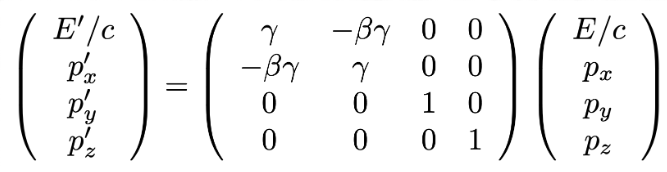

The above matrix is from a slide in-class for a boost along the x-axis. Our choice of x-axis / z-axis momentum is arbitrary, since we'll end up aligning our vectors with the direction of momentum in the end.

The inverse matrix is: $$ \begin{pmatrix} \frac{1}{\gamma - \gamma \beta^2} & \frac{\beta}{\gamma - \gamma\beta^2} & 0 & 0 \\ \frac{\beta}{\gamma - \gamma\beta^2} & \frac{1}{\gamma - \gamma \beta^2} & 0 & 0 \\ 0 & 0 & 1 & 0 \\ 0 & 0 & 0 & 1 \end{pmatrix} \begin{pmatrix} 40.62 \\ 40.62 \\ 0 \\ 0 \end{pmatrix} = \begin{pmatrix} E/c \\ p_x \\ p_y \\ p_z \end{pmatrix} $$

```python
(m/2) * (1+beta) / (gamma - (gamma*beta**2))
```

```
191.3783344124855
```

**Q2**

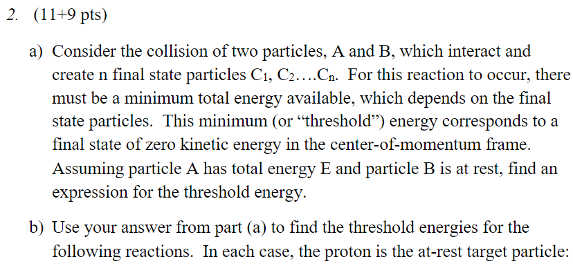

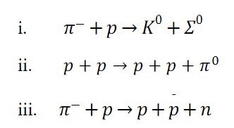

The combined momentum and mass of the inital particles must equal the mass of each resultant particle.

$E_2 \not > E_1$  
$E_1 \geq E_2$  
$\min(E_1)=E_2$

$$ E_A + E_B = \sum_{i=1}^n E_{C_i} \\ E^2 = m^2 + p^2 \\ E = \sqrt{m^2+p^2} \\ \sqrt{m_A^2 + p_A^2} + m_B = \sum_{i=1}^n m_{C_i} \\ p_A = \sqrt{\left(\sum_{i=1}^n m_{C_i}-m_B\right)^2 - m_A^2} $$

Below I calculate the momentum needed for each reaction

```python
# mass MeV, natural units c=1
m_pi = 140 #+/-
m_pi0 = 135 #just following pdg
m_p = 938
m_K0 = 497
m_S0 = 1193
m_n = 940

# i.
E = m_K0+m_S0-m_p
print(f'i. total energy: {E} MeV')
momentum = (E**2-m_pi**2)**(1/2)
print(f'i. pion momentum: {momentum:.0f} MeV \n')

# ii.
E = m_p + m_p + m_pi0 - m_p
print(f'ii. total energy: {E} MeV')
momentum = (E**2- m_p**2)**(1/2)
print(f'ii. proton momentum: {momentum:.0f} MeV \n')

# iii.
E = m_p+m_p+m_n-m_p
print(f'iii. total energy: {E} MeV')
momentum = (E**2-m_pi**2)**(1/2)
print(f'iii. pion momentum: {momentum:.0f} MeV \n')
```

```
i. total energy: 752 MeV
i. pion momentum: 739 MeV

ii. total energy: 1073 MeV
ii. proton momentum: 521 MeV

iii. total energy: 1878 MeV
iii. pion momentum: 1873 MeV
```

**Q3**

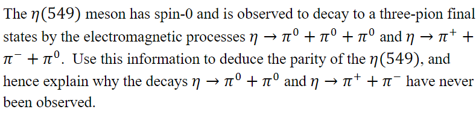

Pions have odd-parity (-1), and the lack of spin (angular momentum) of the $\eta(549)$ meson means that the parity before and after decay is conserved/equivalent.

Thus, the parity of $\eta(549) = P_\pi^3 = (-1)^3 = -1$, and the forbidden decays have incorrect parity to occur

$$ \eta \rightarrow \pi + \pi \\ -1 \neq (-1)(-1)=1 $$

Notice I do not specify types of pions, this is because they all have the same parity.

**Q4**

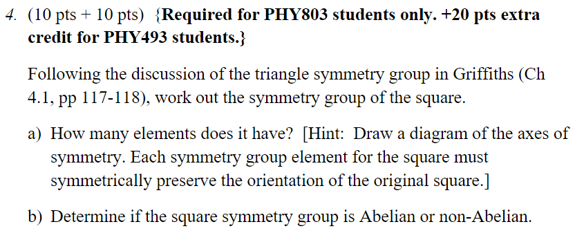

The Cayley table shows all elements and their products

\begin{array}{c|cccccccc} & I & r & r^2 & r^3 & f_x & f_y & f_{AC} & f_{BD} \\ \hline I & I & r & r^2 & r^3 & f_x & f_y & f_{AC} & f_{BD} \\ r & r & r^2 & r^3 & I & f_{AC} & f_{BD} & f_y & f_x \\ r^2 & r^2 & r^3 & I & r & f_y & f_x & f_{BD} & f_{AC} \\ r^3 & r^3 & I & r & r^2 & f_{BD} & f_{AC} & f_x & f_y \\ f_x & f_x & f_{BD} & f_{AC} & f_y & I & r^2 & r^3 & r \\ f_y & f_y & f_{AC} & f_x & f_{BD} & r^2 & I & r & r^3 \\ f_{AC} & f_{AC} & f_x & f_{BD} & f_y & r^3 & r & I & r^2 \\ f_{BD} & f_{BD} & f_y & f_{AC} & f_x & r & r^3 & r^2 & I \\ \end{array}

$r$ represents a 90 degree rotation. Only $90$, $90^2=180$, $90^3=270$, and $90^4=I$ rotations are allowed in the square group. $r$ can be clockwise or counterclockwise, but cw $r$ is the same as ccw $r^3$, so it isn't really a new action. The same is true for "flipping" 180 degrees cw or ccw. The above table uses ccw $r$

Flips along the x-axis and y-axis through the center of the square also have closure (swap A,B with C,D or A,C with B,D), alongside flips on the diagonals (swap BC or AD).

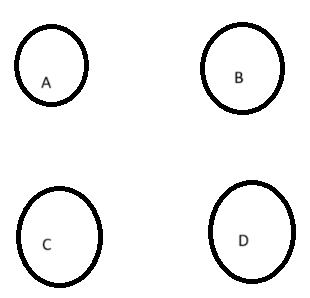

r -> f_x  
B D -> A C  
A C -> B D

f_x -> r  
C D -> D B  
A B -> C A